# Trabajo Integrador - Módulos 3, 4 y 5

### Evolución de los tópicos en el tiempo

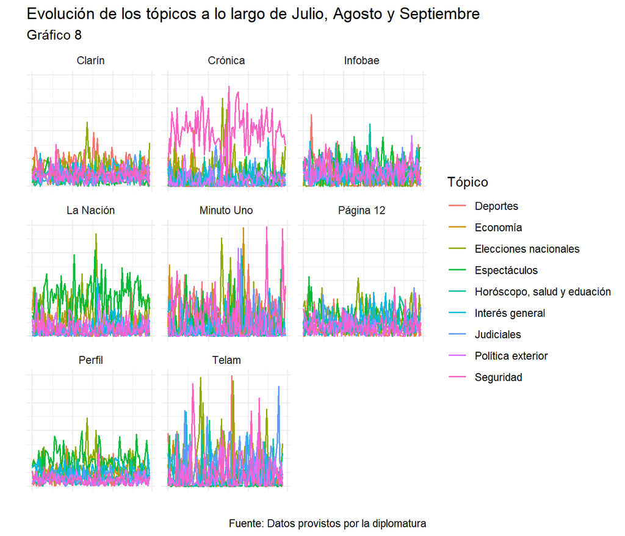

```r
corpus_tidy_topic %>%
  group_by(fecha, topic, medio, label_topic)%>%
  summarise(mean=mean(gamma))%>%
  mutate(topic=as.factor(topic)) %>%
  ggplot(aes(fecha, mean))+
  geom_line(aes(color=label_topic),stat = "identity", size=0.6)+
  theme_minimal()+
  theme(axis.text.x = element_blank(), axis.text.y = element_blank())+
  facet_wrap(~medio)+
  labs(x="", y="",title = "Evolución de los tópicos a lo largo de Julio, Agosto y Septiembre",
       subtitle = "Gráfico 8",
       caption="Fuente: Datos provistos por la diplomatura",
       color="Tópico")
```

Se destaca en el mes de julio, un crecimiento de los temas de seguridad y elecciones nacionales en Télam, y un aumento de noticias sobre espectáculos en la nación. En el mes de agosto se evidencia un crecimiento, tanto en Clarín como en La Nación de noticias vinculadas a las elecciones nacionales. Casi todos los medios presentan durante el mes de agosto un crecimiento en la temática de elecciones nacionales, en concordancia con las PASO. Infobae es el medio que menos noticias presenta sobre las elecciones nacionales en ese mes y Página 12 presenta un crecimiento pero leve, en comparación con el resto de los medios. Luego, durante el mes de septiembre, post PASO, se destacan una gran cantidad de noticias sobre seguridad y judiciales en Télam. En minuto 1, también aparecen días de picos de noticias sobre seguridad, mientras qué La nación se destaca por presentar nuevamente muchas noticias sobre espectáculos. Durante los tres meses en cuestión Crónica presenta una gran cantidad de noticias sobre temas vinculados a la seguridad. Se mantiene bastante estable esta tendencia a lo largo de los tres meses observados.

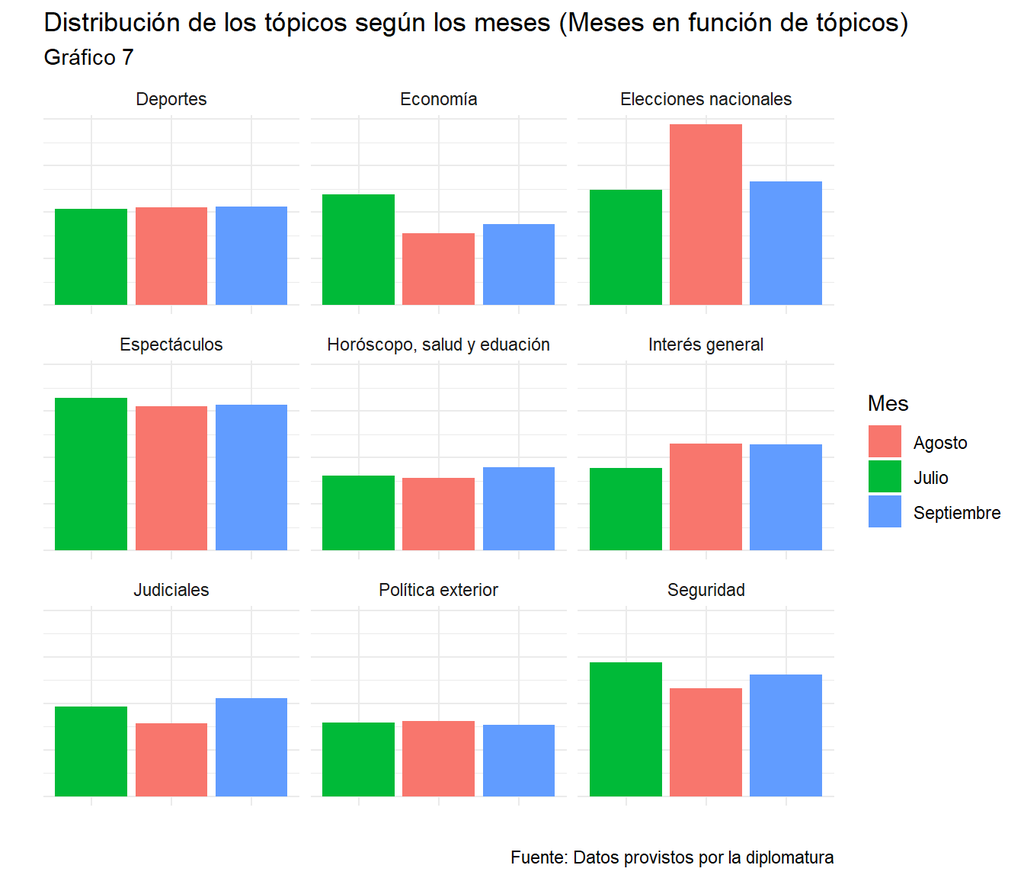

```r
corpus_tidy_topic <- corpus_tidy_topic %>%
  filter(!is.na(fecha)) %>%
  mutate(mes=as.factor(mes)) %>%
  mutate(fecha=as.Date(fecha))

corpus_tidy_topic %>%
  group_by(mes, topic, label_mes, label_topic) %>%
  summarise(mean = mean(gamma)) %>%
  drop_na() %>%
  ggplot(aes(x=mes, y=mean, fill=label_mes)) +
    geom_col(stat="identity",position='dodge') +
    facet_wrap(~label_topic) +
    theme_minimal()+
  theme(axis.text.x = element_blank(), axis.text.y = element_blank())+
  labs(y="",
       x="",
       title = "Distribución de los tópicos según los meses (Meses en función de tópicos)",
       subtitle="Gráfico 7",
       caption="Fuente: Datos provistos por la diplomatura",
       fill="Mes")
```